# July2024: END SEMESTER ASSESSMENT (ESA)

# UE20CS933-NATURAL LANGUAGE PROCESSING

1. Use the data.csv dataset as provided in the notebook as Pandas DataFrame and process it as questioned below:

a) Pre-Process the text feature as questioned below:

- Remove the accented characters from the text feature.
- Remove digits from the text feature.
- Remove punctuations from the text feature.
- Remove stopwords from the text feature.
- Eliminate multiple spaces from the text feature. Note: Save this preprocessed text feature and use it as a feature for next question

b) Find out the 5 most frequent words in the text corpus (from the preprocessed output of the previous question 1 a))

c) Vectorize the preprocessed text feature by building/training a skip-gram word2vec model. Use this skip-gram word2vec model to fetch the 5 most similar words for the word 'food'.

d) Vectorize the preprocessed text feature by building/training a CBOW word2vec model. Use this CBOW word2vec model to fetch the 5 most similar words for the word 'food'. Is the output different from previous skip-gram's output?

1. a) Convert textual output (of question 1 a) into numerical using countvectorizer.

b) Covert textual output (of question 1 a) into numerical using TFIDF Vectorizer.

c) Build LSTM multiclass text classification model on the cleaned dataset output (of question 1 a) using Keras Libraires.

d) Show the confusion matrix and compute accuracy from the model and interpret it.

```python
import pandas as pd
import numpy as np
import re
import unicodedata
from nltk.corpus import stopwords
from nltk.tokenize import word_tokenize
from gensim.parsing.preprocessing import PorterStemmer, remove_stopwords
import string
from sklearn.feature_extraction.text import CountVectorizer
from sklearn.feature_extraction.text import TfidfVectorizer
from sklearn.model_selection import train_test_split
from sklearn.linear_model import LogisticRegression
from sklearn.metrics import accuracy_score
```

```python
import pandas as pd
df = pd.read_csv("data.csv")
df.head()
```

|  | tweet_id | airline_sentiment | airline_sentiment_confidence | negativereason | negativereason_confidence | airline | airline_sentiment_gold | name | negativereason_gold | retweet_count | text | tweet_coord | tweet_created | tweet_location | user_timezone |
| --- | --- | --- | --- | --- | --- | --- | --- | --- | --- | --- | --- | --- | --- | --- | --- |
| 0 | 570306133677760513 | neutral | 1.0000 | NaN | NaN | Virgin America | NaN | cairdin | NaN | 0 | @VirginAmerica What @dhepburn said. | NaN | 2015-02-24 11:35:52 -0800 | NaN | Eastern Time (US & Canada) |
| 1 | 570301130888122368 | positive | 0.3486 | NaN | 0.0000 | Virgin America | NaN | jnardino | NaN | 0 | @VirginAmerica plus you've added commercials t... | NaN | 2015-02-24 11:15:59 -0800 | NaN | Pacific Time (US & Canada) |
| 2 | 570301083672813571 | neutral | 0.6837 | NaN | NaN | Virgin America | NaN | yvonnalynn | NaN | 0 | @VirginAmerica I didn't today... Must mean I n... | NaN | 2015-02-24 11:15:48 -0800 | Lets Play | Central Time (US & Canada) |
| 3 | 570301031407624196 | negative | 1.0000 | Bad Flight | 0.7033 | Virgin America | NaN | jnardino | NaN | 0 | @VirginAmerica it's really aggressive to blast... | NaN | 2015-02-24 11:15:36 -0800 | NaN | Pacific Time (US & Canada) |
| 4 | 570300817074462722 | negative | 1.0000 | Can't Tell | 1.0000 | Virgin America | NaN | jnardino | NaN | 0 | @VirginAmerica and it's a really big bad thing... | NaN | 2015-02-24 11:14:45 -0800 | NaN | Pacific Time (US & Canada) |

```python
df.info()
```

```
<class 'pandas.core.frame.DataFrame'>
RangeIndex: 14640 entries, 0 to 14639
Data columns (total 15 columns):
 #   Column                        Non-Null Count  Dtype
---  ------                        --------------  -----
 0   tweet_id                      14640 non-null  int64
 1   airline_sentiment             14640 non-null  object
 2   airline_sentiment_confidence  14640 non-null  float64
 3   negativereason                9178 non-null   object
 4   negativereason_confidence     10522 non-null  float64
 5   airline                       14640 non-null  object
 6   airline_sentiment_gold        40 non-null     object
 7   name                          14640 non-null  object
 8   negativereason_gold           32 non-null     object
 9   retweet_count                 14640 non-null  int64
 10  text                          14640 non-null  object
 11  tweet_coord                   1019 non-null   object
 12  tweet_created                 14640 non-null  object
 13  tweet_location                9907 non-null   object
 14  user_timezone                 9820 non-null   object
dtypes: float64(2), int64(2), object(11)
memory usage: 1.7+ MB
```

```python
# Download necessary NLTK data
nltk.download('stopwords')
```

```
True
```

```python
# Define the preprocessing function
def preprocess(text):
    # Remove accented characters
    text = unicodedata.normalize('NFKD', text).encode('ascii', 'ignore').decode('utf-8', 'ignore')

    # Remove digits
    text = re.sub(r'\d+', '', text)

    # Remove punctuations
    text = text.translate(str.maketrans('', '', string.punctuation))

    # Remove stopwords
    stop_words = set(stopwords.words('english'))
    text = ' '.join([word for word in text.split() if word.lower() not in stop_words])

    # Eliminate multiple spaces
    text = re.sub(r'\s+', ' ', text).strip()

    return text
```

```python
# Apply preprocessing
df['cleaned_text'] = df['text'].apply(preprocess)
```

```python
# Create a new DataFrame with only the text and cleaned_text columns
df_text_cleaned = df[['text', 'cleaned_text']]
df_text_cleaned.head()
```

|  | text | cleaned_text |
| --- | --- | --- |
| 0 | @VirginAmerica What @dhepburn said. | VirginAmerica dhepburn said |
| 1 | @VirginAmerica plus you've added commercials t... | VirginAmerica plus youve added commercials exp... |
| 2 | @VirginAmerica I didn't today... Must mean I n... | VirginAmerica didnt today Must mean need take ... |
| 3 | @VirginAmerica it's really aggressive to blast... | VirginAmerica really aggressive blast obnoxiou... |
| 4 | @VirginAmerica and it's a really big bad thing... | VirginAmerica really big bad thing |

### b) Find the 5 Most Frequent Words

Now, let’s find the 5 most frequent words in the preprocessed text corpus.

```python
from collections import Counter

# Tokenize the cleaned text
all_words = ' '.join(df['cleaned_text']).split()
word_freq = Counter(all_words)

# Get the 5 most common words
most_common_words = word_freq.most_common(5)
print(most_common_words)
```

```
[('united', 3819), ('flight', 3156), ('USAirways', 2936), ('AmericanAir', 2920), ('SouthwestAir', 2404)]
```

### c) Vectorize Using Skip-Gram Word2Vec Model

Next, we’ll build and train a skip-gram Word2Vec model and find the 5 most similar words to ‘food’.

```python
from gensim.models import Word2Vec

# Tokenize the cleaned text
sentences = [text.split() for text in df['cleaned_text']]

# Train the skip-gram model
skipgram_model = Word2Vec(sentences, vector_size=100, window=5, min_count=1, sg=1)

# Find the 5 most similar words to 'food'
similar_words_skipgram = skipgram_model.wv.most_similar('food', topn=5)
print(similar_words_skipgram)
```

```
[('baby', 0.9939871430397034), ('clean', 0.9934775233268738), ('wanna', 0.9933609366416931), ('warm', 0.993285596370697), ('bucks', 0.9931348562240601)]
```

### d) Vectorize Using CBOW Word2Vec Model

```python
# Train the CBOW model
cbow_model = Word2Vec(sentences, vector_size=100, window=5, min_count=1, sg=0)

# Find the 5 most similar words to 'food'
similar_words_cbow = cbow_model.wv.most_similar('food', topn=5)
print(similar_words_cbow)
```

```
[('see', 0.9997386336326599), ('fix', 0.9997032284736633), ('use', 0.9996851086616516), ('good', 0.9996503591537476), ('actually', 0.9996486306190491)]
```

### 2 a) Convert Textual Output into Numerical Using CountVectorizer

First, we’ll use CountVectorizer to convert the preprocessed text into numerical data.

```python
from sklearn.feature_extraction.text import CountVectorizer

# Initialize CountVectorizer
count_vectorizer = CountVectorizer()

# Fit and transform the cleaned text
count_vectorized = count_vectorizer.fit_transform(df['cleaned_text'])
print(count_vectorized.toarray())
```

```
[[0 0 0 ... 0 0 0]
 [0 0 0 ... 0 0 0]
 [0 0 0 ... 0 0 0]
 ...
 [0 0 0 ... 0 0 0]
 [0 0 0 ... 0 0 0]
 [0 0 0 ... 0 0 0]]
```

### b) Convert Textual Output into Numerical Using TFIDF Vectorizer

Next, we’ll use TfidfVectorizer to convert the preprocessed text into numerical data.

```python
from sklearn.feature_extraction.text import TfidfVectorizer

# Initialize TfidfVectorizer
tfidf_vectorizer = TfidfVectorizer()

# Fit and transform the cleaned text
tfidf_vectorized = tfidf_vectorizer.fit_transform(df['cleaned_text'])
print(tfidf_vectorized.toarray())
```

```
[[0. 0. 0. ... 0. 0. 0.]
 [0. 0. 0. ... 0. 0. 0.]
 [0. 0. 0. ... 0. 0. 0.]
 ...
 [0. 0. 0. ... 0. 0. 0.]
 [0. 0. 0. ... 0. 0. 0.]
 [0. 0. 0. ... 0. 0. 0.]]
```

### c) Build LSTM Multiclass Text Classification Model Using Keras

Now, let’s build an LSTM model for multiclass text classification using the cleaned dataset.

```python
from sklearn.model_selection import train_test_split
from tensorflow.keras.preprocessing.text import Tokenizer
from tensorflow.keras.preprocessing.sequence import pad_sequences
from tensorflow.keras.models import Sequential
from tensorflow.keras.layers import Embedding, LSTM, Dense, SpatialDropout1D
```

```python
# Prepare the input data and labels
X = df['cleaned_text']
y = pd.get_dummies(df['airline_sentiment']).values  # Convert labels to one-hot encoding

# Tokenization and padding
max_words = 5000  # Use a maximum of 5000 words
max_len = 100  # Limit sequences to 100 words

tokenizer = Tokenizer(num_words=max_words, lower=True)
tokenizer.fit_on_texts(X)
X_tokenized = tokenizer.texts_to_sequences(X)
X_padded = pad_sequences(X_tokenized, maxlen=max_len)

# Split the data into training and testing sets
X_train, X_test, y_train, y_test = train_test_split(X_padded, y, test_size=0.2, random_state=42)
```

```python
# Build the LSTM model
model = Sequential()
model.add(Embedding(max_words, 128))
model.add(SpatialDropout1D(0.2))
model.add(LSTM(100, dropout=0.2, recurrent_dropout=0.2))
model.add(Dense(3, activation='softmax'))  # 3 classes for sentiment
```

```python
# Compile the model
model.compile(loss='categorical_crossentropy', optimizer='adam', metrics=['accuracy'])
```

```python
# Train the model
history = model.fit(X_train, y_train, epochs=5, batch_size=64, validation_data=(X_test, y_test), verbose=2)
```

```
183/183 - 40s - 219ms/step - accuracy: 0.6908 - loss: 0.7447 - val_accuracy: 0.7777 - val_loss: 0.5535
183/183 - 32s - 175ms/step - accuracy: 0.8066 - loss: 0.4850 - val_accuracy: 0.7985 - val_loss: 0.5033
183/183 - 32s - 176ms/step - accuracy: 0.8577 - loss: 0.3823 - val_accuracy: 0.8012 - val_loss: 0.5118
183/183 - 32s - 174ms/step - accuracy: 0.8778 - loss: 0.3214 - val_accuracy: 0.7941 - val_loss: 0.5565
183/183 - 32s - 174ms/step - accuracy: 0.8952 - loss: 0.2808 - val_accuracy: 0.7876 - val_loss: 0.5997
```

```python
# Display the model summary
model.summary()
```

```
Model: "sequential_1"
```

```
┏━━━━━━━━━━━━━━━━━━━━━━━━━━━━━━━━━┳━━━━━━━━━━━━━━━━━━━━━━━━┳━━━━━━━━━━━━━━━┓
┃ Layer (type)                    ┃ Output Shape           ┃       Param # ┃
┡━━━━━━━━━━━━━━━━━━━━━━━━━━━━━━━━━╇━━━━━━━━━━━━━━━━━━━━━━━━╇━━━━━━━━━━━━━━━┩
│ embedding_1 (Embedding)         │ (64, 100, 128)         │       640,000 │
├─────────────────────────────────┼────────────────────────┼───────────────┤
│ spatial_dropout1d_1             │ (64, 100, 128)         │             0 │
│ (SpatialDropout1D)              │                        │               │
├─────────────────────────────────┼────────────────────────┼───────────────┤
│ lstm_1 (LSTM)                   │ (64, 100)              │        91,600 │
├─────────────────────────────────┼────────────────────────┼───────────────┤
│ dense_1 (Dense)                 │ (64, 3)                │           303 │
└─────────────────────────────────┴────────────────────────┴───────────────┘
```

```
 Total params: 2,195,711 (8.38 MB)
```

```
 Trainable params: 731,903 (2.79 MB)
```

```
 Non-trainable params: 0 (0.00 B)
```

```
 Optimizer params: 1,463,808 (5.58 MB)
```

### d) Show Confusion Matrix and Compute Accuracy

```python
from sklearn.metrics import confusion_matrix, accuracy_score
import seaborn as sns
import matplotlib.pyplot as plt

# Predict on the validation set
y_pred = model.predict(X_padded)
y_pred_classes = np.argmax(y_pred, axis=1)
y_true = np.argmax(y, axis=1)
```

```
458/458 ━━━━━━━━━━━━━━━━━━━━ 25s 54ms/step
```

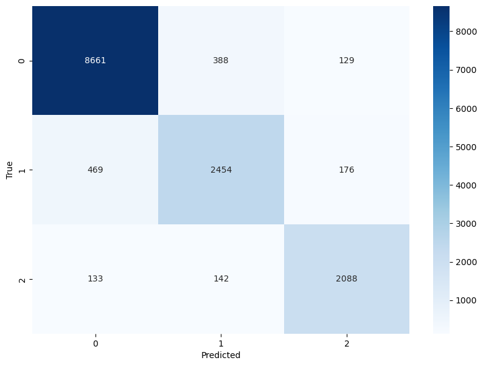

```
Accuracy: 0.901844262295082
```

```python
# Compute confusion matrix
conf_matrix = confusion_matrix(y_true, y_pred_classes)

# Plot confusion matrix
plt.figure(figsize=(10, 7))
sns.heatmap(conf_matrix, annot=True, fmt='d', cmap='Blues')
plt.xlabel('Predicted')
plt.ylabel('True')
plt.show()

# Compute accuracy
accuracy = accuracy_score(y_true, y_pred_classes)
print(f'Accuracy: {accuracy}')
```